# 6. Analysis of longitudinal data

In this chapter I perform analysis of longitudinal data based on datasets RATS and BPRS. The analysis ought to follow those in the book Multivariate Analysis for the Behavioral Sciences (MABS) for chapters 8 and 9. Before the analysis, some data wrangling is involved.

## Data Wrangling

Before analysis, the data is manipulated from wide form to long form. The analysis is performed in the R-file “meet_and_repeat.R” that can be found in the github repository. Also, the datasets are described there.

## Analysis 1: Chapter 8 of MABS using the RATS data

As suggested earlier, the analysis follows that of chapters 8 and 9 in the book MABS. The first part deals with dataset RATS and Chapter 8 of MABS.

### Dataset RATS explained

RATS dataset is from Crowder and Hand (1990), who studied the effects of of different diets on the weight of three groups of rats. As shown below, using the dataset in the long form, the variables are ID (number associated with each rat), Group (associated with one of the three diets), WD (the initial time of observation), Weight (the weight of the rat measured at different points of time) and Time (the time of observation).

```r
rm(list=ls())
library(dplyr)
```

```r
library(stringr)
library(ggplot2)
library(GGally)
library(tidyr)
library(lme4)
BPRS <- read.table("https://raw.githubusercontent.com/KimmoVehkalahti/MABS/master/Examples/data/BPRS.txt", sep  =" ", header = T)
RATS <- read.table("https://raw.githubusercontent.com/KimmoVehkalahti/MABS/master/Examples/data/rats.txt", stringsAsFactors = F, na.strings = "..")
RATSL<-read.table("RATSL.txt")
head(RATSL)
```

```
##   ID Group  WD Weight Time
## 1  1     1 WD1    240    1
## 2  2     1 WD1    225    1
## 3  3     1 WD1    245    1
## 4  4     1 WD1    260    1
## 5  5     1 WD1    255    1
## 6  6     1 WD1    260    1
```

```r
str(RATSL)
```

```
## 'data.frame':    176 obs. of  5 variables:
##  $ ID    : int  1 2 3 4 5 6 7 8 9 10 ...
##  $ Group : int  1 1 1 1 1 1 1 1 2 2 ...
##  $ WD    : Factor w/ 11 levels "WD1","WD15","WD22",..: 1 1 1 1 1 1 1 1 1 1 ...
##  $ Weight: int  240 225 245 260 255 260 275 245 410 405 ...
##  $ Time  : int  1 1 1 1 1 1 1 1 1 1 ...
```

```r
summary(RATSL)
```

```
##        ID            Group            WD         Weight
##  Min.   : 1.00   Min.   :1.00   WD1    :16   Min.   :225.0
##  1st Qu.: 4.75   1st Qu.:1.00   WD15   :16   1st Qu.:267.0
##  Median : 8.50   Median :1.50   WD22   :16   Median :344.5
##  Mean   : 8.50   Mean   :1.75   WD29   :16   Mean   :384.5
##  3rd Qu.:12.25   3rd Qu.:2.25   WD36   :16   3rd Qu.:511.2
##  Max.   :16.00   Max.   :3.00   WD43   :16   Max.   :628.0
##                                 (Other):80
##       Time
##  Min.   : 1.00
##  1st Qu.:15.00
##  Median :36.00
##  Mean   :33.55
##  3rd Qu.:50.00
##  Max.   :64.00
##
```

```r
glimpse(RATSL)
```

```
## Observations: 176
## Variables: 5
## $ ID     <int> 1, 2, 3, 4, 5, 6, 7, 8, 9, 10, 11, 12, 13, 14, 15, 16, ...
## $ Group  <int> 1, 1, 1, 1, 1, 1, 1, 1, 2, 2, 2, 2, 3, 3, 3, 3, 1, 1, 1...
## $ WD     <fct> WD1, WD1, WD1, WD1, WD1, WD1, WD1, WD1, WD1, WD1, WD1, ...
## $ Weight <int> 240, 225, 245, 260, 255, 260, 275, 245, 410, 405, 445, ...
## $ Time   <int> 1, 1, 1, 1, 1, 1, 1, 1, 1, 1, 1, 1, 1, 1, 1, 1, 8, 8, 8...
```

### Graphical displays of longitudinal data and comparison of groups

This section focuses on displaying the data in a way that something can be learned. First, lets plot the data by groups.

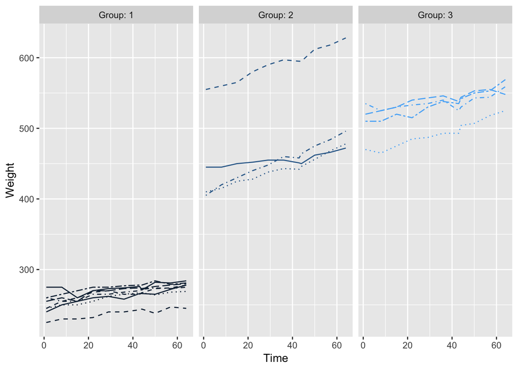

```r
# Plot the RATSL data by groups
ggplot(RATSL, aes(x = Time, y = Weight,col=Group, linetype = as.factor(ID)))+geom_line()+scale_linetype_manual(values = rep(1:10, times=4))+facet_grid(. ~ Group, labeller = label_both) +theme(legend.position = "none")
```

As suggested by the plots, in all groups and for all individuals, the weight seems to increase in time. What stands out in the plots is that there are big differences in the weights of the rats in different groups such that those in group 1 are the lightest and those in the group are the heaviest with the exception of one sturdy rat in group two that is a clear outlier.

Overall, the plot support the tracking phenomenom mentioned in MABS that the heavier rats is in the beginning are often the heaviest in the end as well.

```r
# Scale RATSL, new data RATSL1
RATSL1 <- RATSL %>%
group_by(Time) %>%
mutate(scaled_weight=(Weight-mean(Weight))/sd(Weight)) %>%
ungroup()
glimpse(RATSL1)
```

```
## Observations: 176
## Variables: 6
## $ ID            <int> 1, 2, 3, 4, 5, 6, 7, 8, 9, 10, 11, 12, 13, 14, 1...
## $ Group         <int> 1, 1, 1, 1, 1, 1, 1, 1, 2, 2, 2, 2, 3, 3, 3, 3, ...
## $ WD            <fct> WD1, WD1, WD1, WD1, WD1, WD1, WD1, WD1, WD1, WD1...
## $ Weight        <int> 240, 225, 245, 260, 255, 260, 275, 245, 410, 405...
## $ Time          <int> 1, 1, 1, 1, 1, 1, 1, 1, 1, 1, 1, 1, 1, 1, 1, 1, ...
## $ scaled_weight <dbl> -1.0011429, -1.1203857, -0.9613953, -0.8421525, ...
```

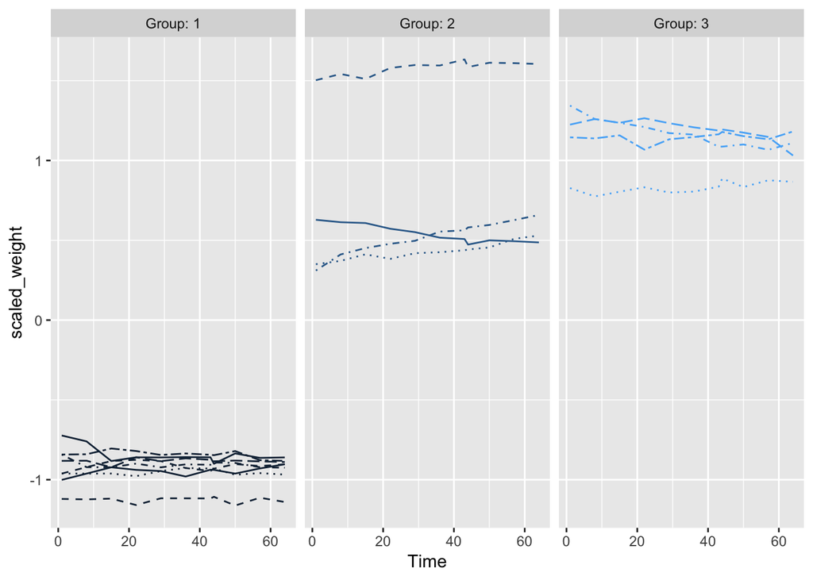

```r
# Plot scaled data by groups
ggplot(RATSL1, aes(x = Time, y = scaled_weight, group=ID, col=Group, linetype=as.factor(ID)))+geom_line()+scale_linetype_manual(values = rep(1:10, times=4))+facet_grid(. ~ Group, labeller = label_both) +theme(legend.position = "none")
```

From the scaled data it appears that the growth rates seem to be the same among groups.

Next, means and standard error of groups are studied.

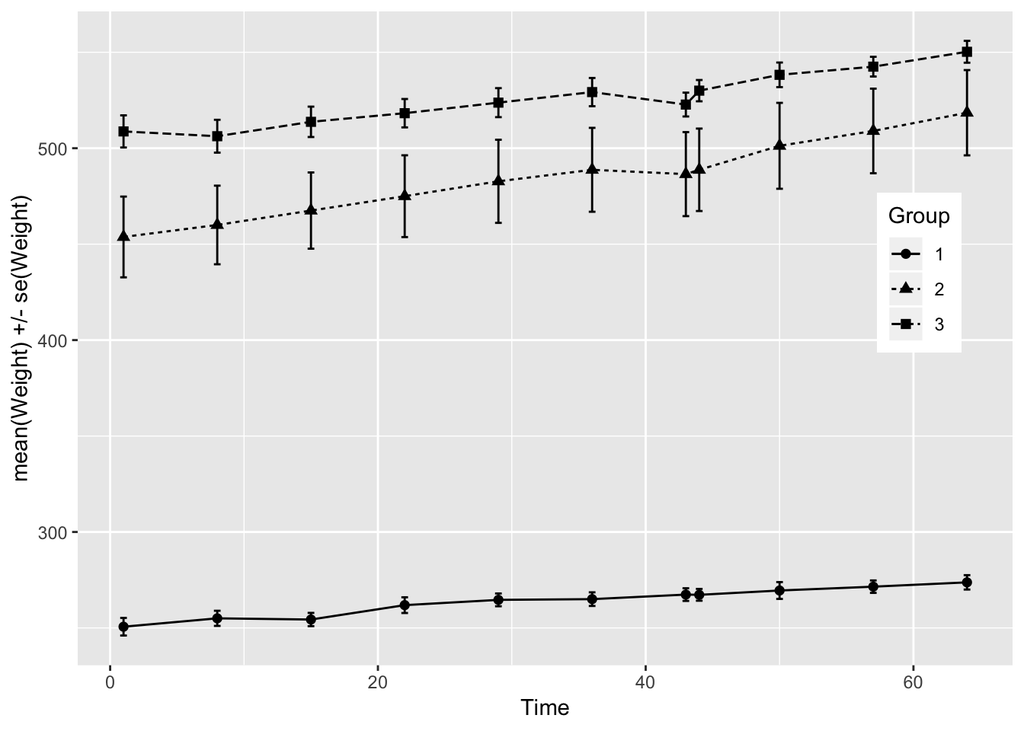

```r
n <- RATSL1$Time %>% unique() %>% length()
RATSL1$Group<-factor(RATSL1$Group)
RATSL2 <- RATSL1 %>%
group_by(Group, Time) %>%
summarise(mean = mean(Weight), se = sd(Weight)/sqrt(n)) %>%
ungroup()
#Plot profiles
ggplot(RATSL2, aes(x = Time, y = mean, linetype = Group, shape = Group)) +
geom_line() +
geom_point(size=2) +
geom_errorbar(aes(ymin=mean-se, ymax=mean+se, linetype="1"), width=0.5) +
theme(legend.position = c(0.9,0.6)) +
scale_y_continuous(name = "mean(Weight) +/- se(Weight)")
```

The plot above suggests that the second group has the highest variation, which is probably driven by the sturdy outlier rat. The second highest variation variation was in the third group and the smallest in the first group. The mean weights grew in all groups and the highest mean is in the third group, second highest in the second group and the smallest in the first group.

### Summary measure analysis of longitudinal data

The summary measure analysis of the rats is performed with boxplots. To make the comparison more meaningful, the sturdy outlier rat from group 2 is filtered.

```r
RATSL3 <- RATSL %>%
filter(Time > 1) %>%
group_by(Group, ID) %>%
summarise(mean=mean(Weight) ) %>%
ungroup()
#look at the data
glimpse(RATSL3)
```

```
## Observations: 16
## Variables: 3
## $ Group <int> 1, 1, 1, 1, 1, 1, 1, 1, 2, 2, 2, 2, 3, 3, 3, 3
## $ ID    <int> 1, 2, 3, 4, 5, 6, 7, 8, 9, 10, 11, 12, 13, 14, 15, 16
## $ mean  <dbl> 263.2, 238.9, 261.7, 267.2, 270.9, 276.2, 274.6, 267.5, ...
```

```r
#structure of the data
str(RATSL3)
```

```
## Classes 'tbl_df', 'tbl' and 'data.frame':    16 obs. of  3 variables:
##  $ Group: int  1 1 1 1 1 1 1 1 2 2 ...
##  $ ID   : int  1 2 3 4 5 6 7 8 9 10 ...
##  $ mean : num  263 239 262 267 271 ...
```

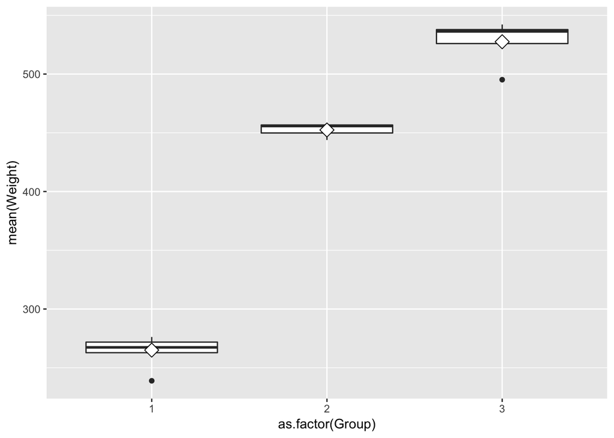

```r
#remove the fat ourlier from group 2
RATSL4<-filter(RATSL3, mean<550)
ggplot(RATSL4, aes(x = as.factor(Group), y = mean)) +
geom_boxplot() +
stat_summary(fun.y = "mean", geom = "point", shape=23, size=4, fill = "white") +
scale_y_continuous(name = "mean(Weight)")
```

There still seems to be one outliers in groups 1 and 3. This may explain why the variances in groups 1 and 3 are greater than in group 2. As noted earlier, the groups vary a lot in terms of means.

Last step here is to study if the differences between these three groups are statistically significant, which is done using analysis of variance (ANOVA) (for 2 groups one could use two sample t-tests). Assumptions in ANOVA are that the observations are independent from each other, the data in each group is normally distributed and they have a common variance.

```r
RATS1 <- read.table("https://raw.githubusercontent.com/KimmoVehkalahti/MABS/master/Examples/data/rats.txt")
RATSL5 <- RATSL3 %>% mutate(Baseline = RATS1$WD1)
fit <- lm(mean ~ Baseline + Group, data = RATSL5)
anova(fit)
```

```
## Analysis of Variance Table
##
## Response: mean
##           Df Sum Sq Mean Sq   F value    Pr(>F)
## Baseline   1 253625  253625 1337.3889 1.703e-14 ***
## Group      1     50      50    0.2629    0.6168
## Residuals 13   2465     190
## ---
## Signif. codes:  0 '***' 0.001 '**' 0.01 '*' 0.05 '.' 0.1 ' ' 1
```